# Code Club

Roman Pauli

2023-04-19

# APA-Tables

Many journals require authors to report results in the style required by the American Psychological Association (APA Style).  
The **apaTables** package creates .doc files with tables that conform to APA Style.  
In addition, we will need the **tidyverse** package to prepare our data:

```r
library(apaTables)
library(tidyverse)
```

The **apaTables** package comes with build in data sets we can use for practice, one of which is the **goggles** data set. The **goggles** data set contains four variables:

- **participant** Participant identification number
- **gender** Gender of participant
- **alcohol** Amount alcohol consumed
- **attractiveness** Perceived attractiveness

### Data preparation

Let’s save the **goggles** data set to an object we call **d** and have a look at the few top rows.

```r
d <- goggles
View(d)
```

The Variables *gender* and *alcohol* are characters, i.e. they contain letters instead of numbers. Since we want to do some simple statistical analyses with metric data, we’ll have to recode these two variables into numerics.  
There are several ways to do this. I prefer using the pipe operator **%>%** from the **dyplr** package that comes within **tidyverse**:

```r
d <- d %>%
  mutate(gender = as.numeric(recode(gender,
                          Female = 1,
                          Male = 0))) %>%
  mutate(pints = as.numeric(recode(alcohol,
                          "None" = 0,
                          "2 Pints" = 2,
                          "4 Pints" = 4))) %>%
  relocate(pints, .after = gender) %>%
  select(.,-c(participant, alcohol))
```

The pipe operator allows us to conduct a series of data transformations, neatly organized in a single block of code. We can read the pipe operator as AND THEN, i.e., do this line of code AND THEN do that line of code AND THEN …  
With the new numeric variable *pints*, *alcohol* is redundant in our data frame; also we don’t want to correlate our study variables with the *participant* ID, so we drop *alcohol* and *participant* from the data frame in the last code line of the pipe. As a results we get:

```r
head(d)
```

```
##   gender pints attractiveness
## 1      1     0             65
## 2      1     0             70
## 3      1     0             60
## 4      1     0             60
## 5      1     0             60
## 6      1     0             55
```

### Correlation table

Let’s say we want to do a correlation table of all the study variables.  
Thanks to **apaTables** we don’t have to do any computation for this! We can simply feed our data frame into the **apa.cor.table** function and have the function do the heavy lifting for us:

```r
apa.cor.table(d, filename="Table1_APA.doc", table.number=1)
```

As a result, we get Means, Standard Deviations and Correlations with Confidence Intervals neatly arranged in APA-style and saved as a word.doc to our working directory.

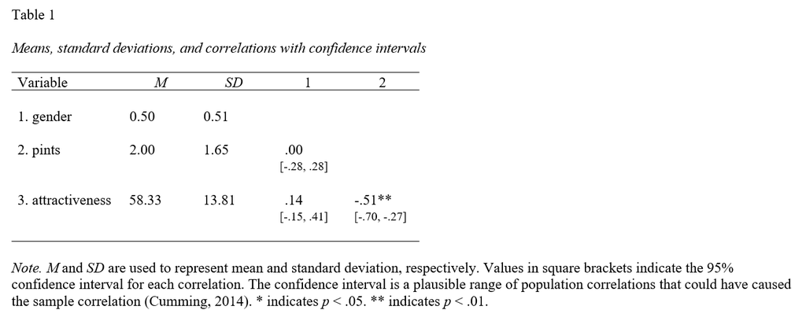

Table 1: Correlations of Study Variables

### Regression table

Suppose we are interested in how the number of pints drunk affects the perceived attractiveness of our subjects, controlling for gender. To do this, we would set up a simple linear regression model and check the results using the **summary** function:

```r
our.model <- lm(attractiveness ~ pints + gender, data = d)
summary(our.model)
```

```
##
## Call:
## lm(formula = attractiveness ~ pints + gender, data = d)
##
## Residuals:
##      Min       1Q   Median       3Q      Max
## -27.8646  -8.8021  -0.0521   8.4245  28.5417
##
## Coefficients:
##             Estimate Std. Error t value Pr(>|t|)
## (Intercept)   65.052      3.229  20.146  < 2e-16 ***
## pints         -4.297      1.057  -4.065  0.00019 ***
## gender         3.750      3.452   1.086  0.28311
## ---
## Signif. codes:  0 '***' 0.001 '**' 0.01 '*' 0.05 '.' 0.1 ' ' 1
##
## Residual standard error: 11.96 on 45 degrees of freedom
## Multiple R-squared:  0.2824, Adjusted R-squared:  0.2505
## F-statistic: 8.854 on 2 and 45 DF,  p-value: 0.0005723
```

Try and copy-paste these results into word or excel and reorganise them in an APA-style tables. I’ll wait …  
Again, this is where **apaTables** comes in handy: We can simply feed our model into the **apa.reg.table** function and get a regression table with confidence intervals based on the **lm** output, neatly organized and saved as a word.doc.

```r
apa.reg.table(our.model, filename = "Table2_APA.doc", table.number = 2)
```

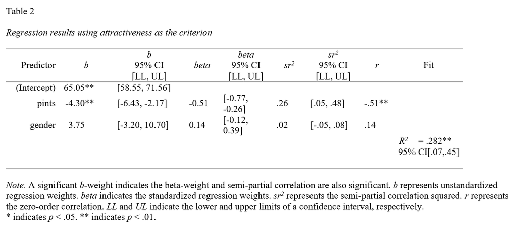

Table 2: Regression Results

Note that our original model summary did not include standardized (i.e., beta) weights, but only unstandardized regression (i.e., b) weights. It would take additional packages and code to have R include these in our output. However, **apaTables** already computed these additional statistics for us and included them in the table without requiring us to do any additional analyses.

### Other Options

**apaTables** holds a number of additional functions to plot the results e.g. from nested regression models or different ANOVA models.  
To learn more, have a look at the [reference manual](https://cran.r-project.org/web/packages/apaTables/apaTables.pdf) or work your way through this [short tutorial](https://dstanley4.github.io/apaTables/articles/apaTables.html).